# Linear Regression - Predicting Individual Medical Costs Billed by Health Insurance

4/18/2020

Myles Lane

## Exploratory Data Analysis

In this dataset there are 1338 observations across 7 variables. Categorical variables include sex (gender), children (number of dependents), smoker (yes or no), and region (respondent residential area). 50.5% are male respondents, 42.9% have no children, 79.5% do not smoke, and 27.2% come from the southeast. Continuous variables include age (in years), BMI (body mass index), and charges (individual medical costs billed by health insurance). The average age in the dataset is 39 with a standard deviation of 14. The average BMI is 30.7 with a standard deviation of 6.1.The average amount of insurance charges is $13,270 with a standard deviation of $12,110.

## Data Visualization

**Sex:** Figure 1 contains many outliers in both groups. It appears that males have a larger interquartile range of about $15,000 while females have a range of $10,000. However, both have a median just under $10,000.

**Age:** Figure 5 shows medical costs by age. The scatterplot appears to show a positive relationship between the two variables. It also shows a weird split into three different sections. One around the cost of $5,000, another at $20,000 and one more at $40,000.

**BMI:** Figure 6. shows medical costs by body mass index. The scatter plot has a regression line that illustrates a positive relationship between the variables. The points are tightly packed from the range of 20 to 40 and spreads out fairly evenly outside of that.

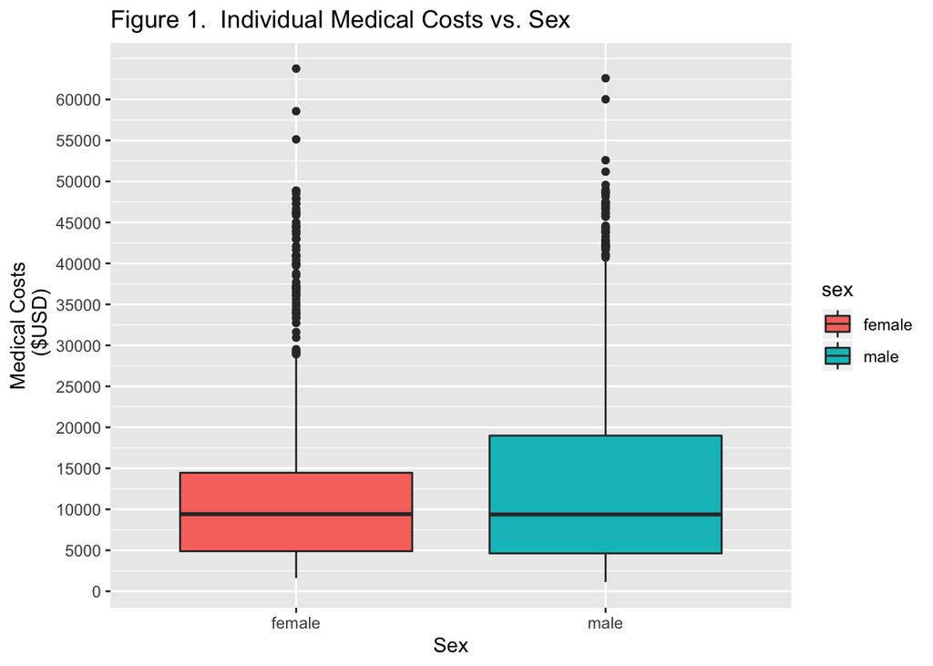

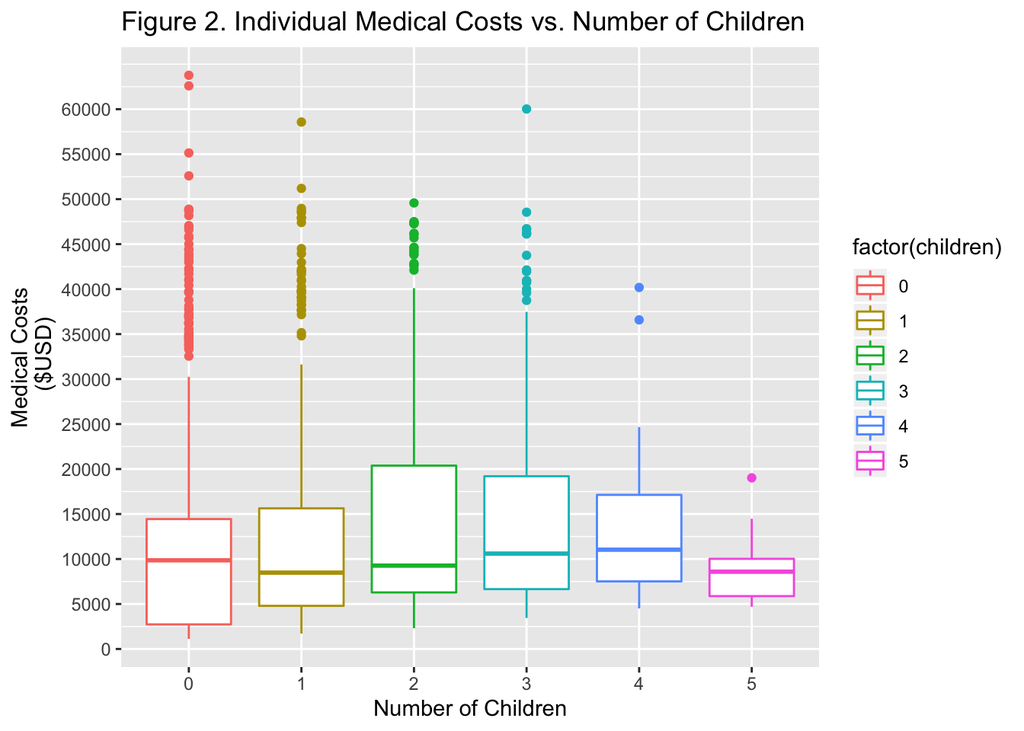

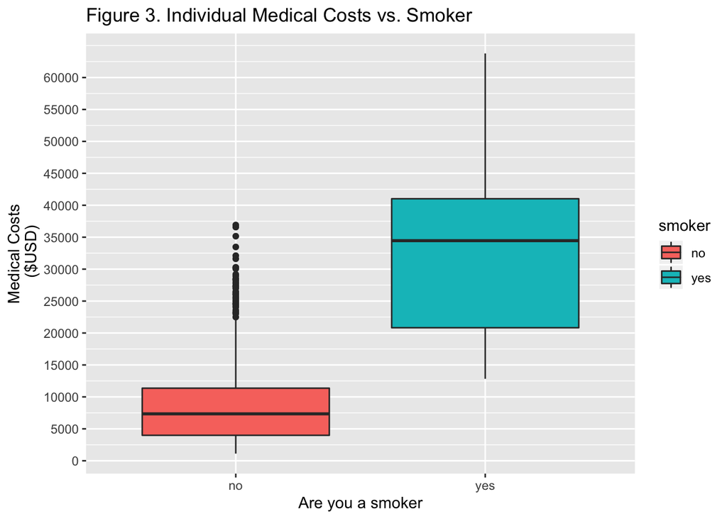

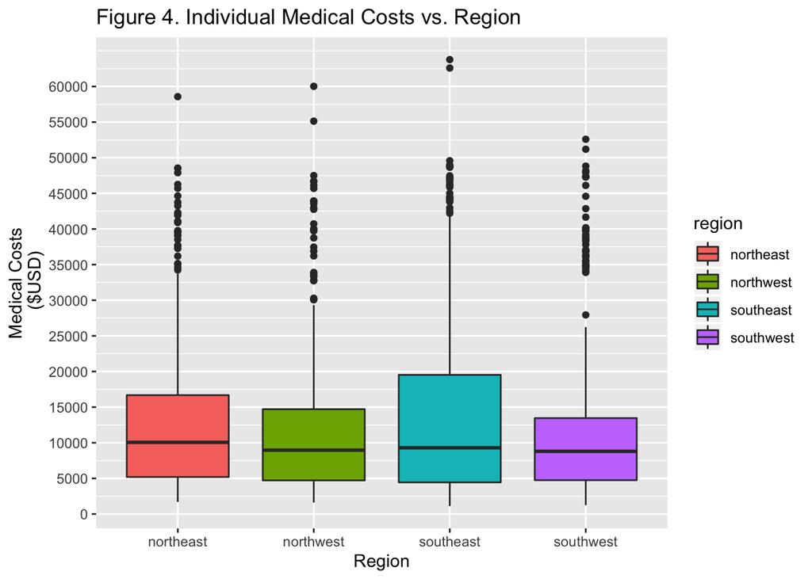

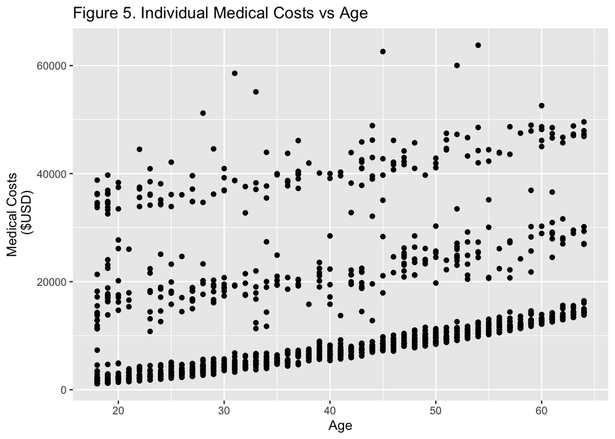

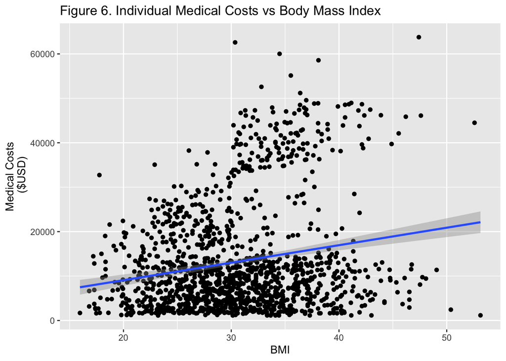

## Multiple Linear Regression Results

**Age:** *For a year increase in age, the amount of individual medical health insurance costs increases by an average of $257.19, holding all other variables constant.*

**Sex:** *The amount of individual medical health insurance costs is on average $128.16 less in males than in females, holding all other variables constant.*

**BMI:** *For a 1-unit increase in BMI, the amount of individual medical health insurance costs increases by an average of $336.91, holding all other variables constant.*

**Children:** *The amount of individual medical health insurance costs is on average $390.98 more in people with 1 dependent than people with none, holding all other variables constant.*

*The amount of individual medical health insurance costs is on average $1635.78 more in people with 2 dependent than people with none, holding all other variables constant.*

*The amount of individual medical health insurance costs is on average $964.34 more in people with 3 dependent than people with none, holding all other variables constant.*

*The amount of individual medical health insurance costs is on average $2947.37 more in people with 4 dependent than people with none, holding all other variables constant.*

*The amount of individual medical health insurance costs is on average $1116.04 more in people with 5 dependent than people with none, holding all other variables constant.*

**Smoker:** *The amount of individual medical health insurance costs is on average $23,836 more in smokers than non-smokers, holding all other variables constant.*

**Region:** *The amount of individual medical health insurance costs is on average $380.04 less in people from the northwest than people from the northeast, holding all other variables constant.*

*The amount of individual medical health insurance costs is on average $1033.14 less in people from the southeast than people from the northeast, holding all other variables constant.*

*The amount of individual medical health insurance costs is on average $952.89 less in people from the southwest than people from the northeast, holding all other variables constant.*

## Linear Regression Assumptions

According to the Scale-Location graph, it appears that the data violates the homoscedasticity assumption because the points are not randomly spread out and the line has a positive slope.

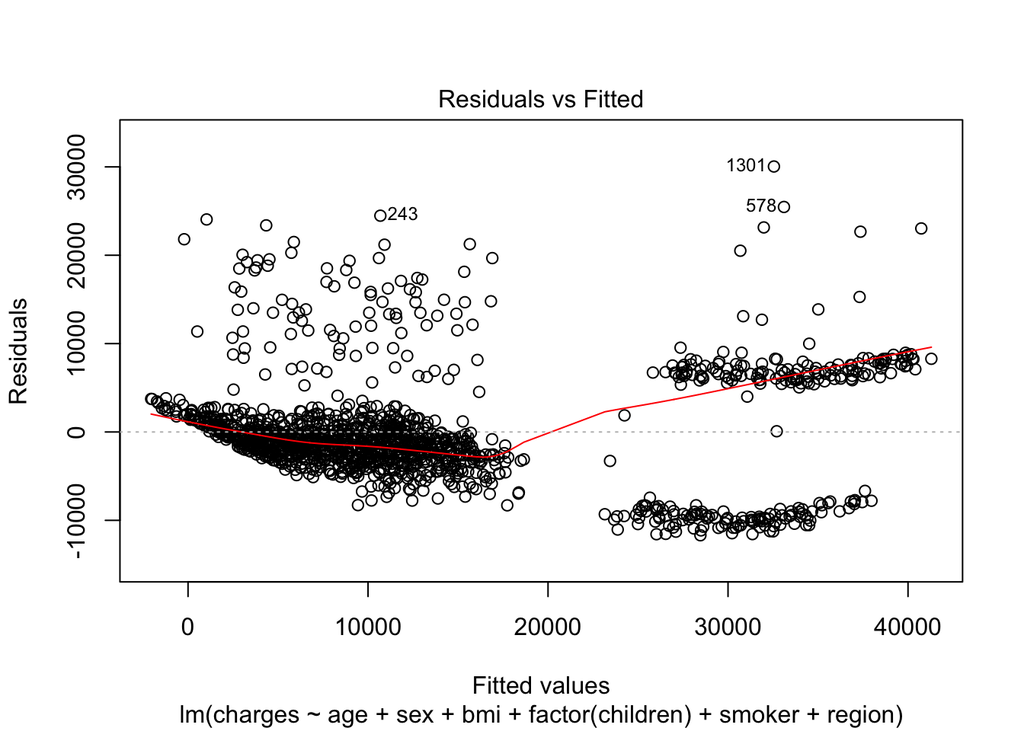

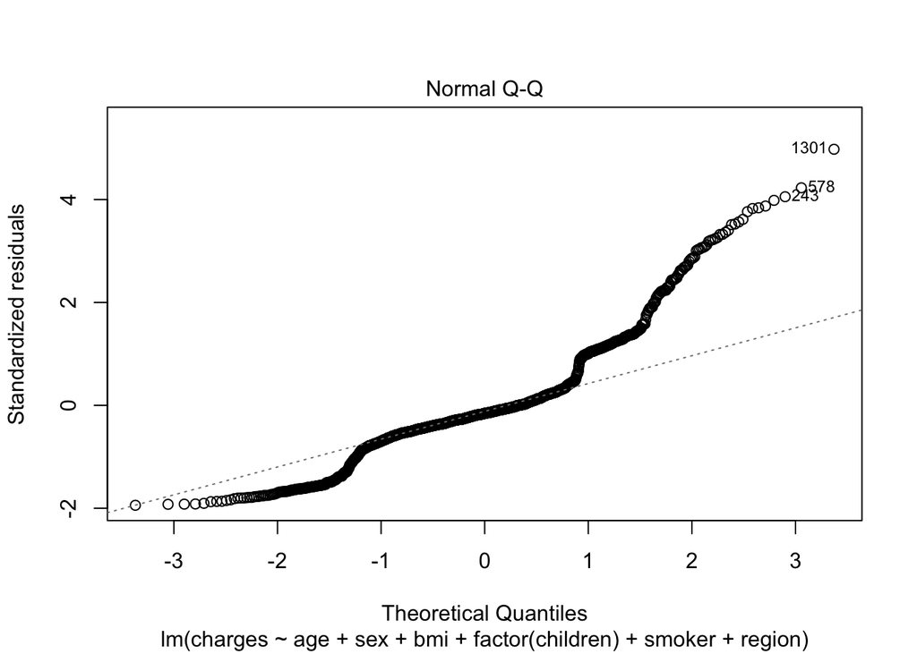

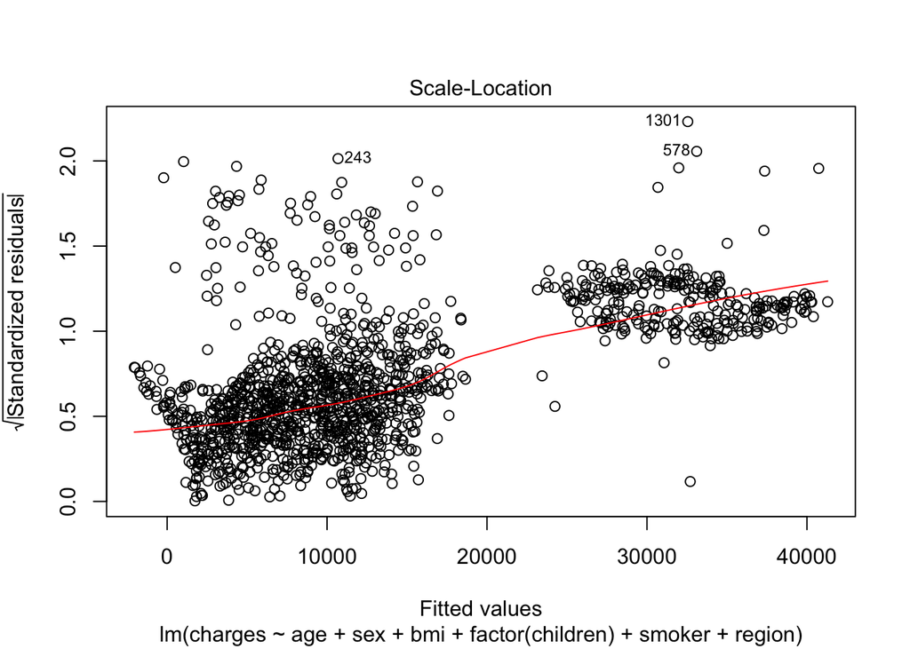

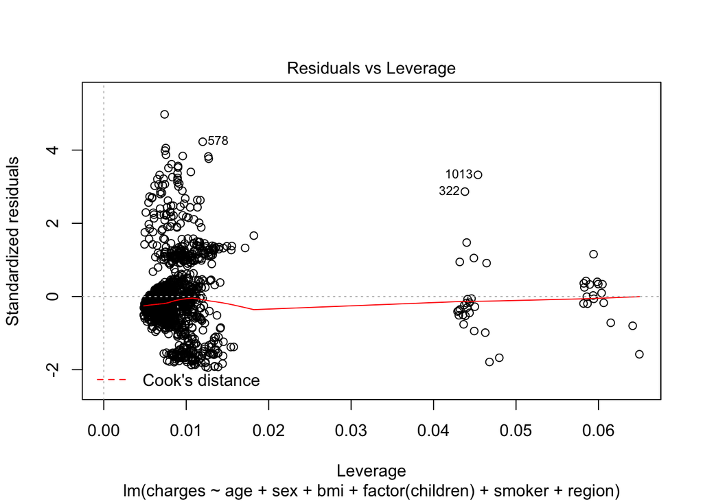